# #Agents: Sample Statistics 2020

This is a documentation of the #Agents -data. The data was collected in between 9.12.2019 – 19.1.2020 as a telephone survey from a gender and age - balanced sample of 15-19 year-old finnish adolescents. The total sample size is 800. An average interview took ~30 minutes and the sample was drawn from the civil registry of Finland. All together 24269 phone numbers were contacted during the sampling period.

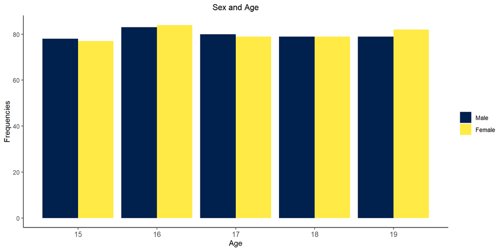

Regarding age or gender the over/underrepresentations were less than 1% (see also Table 2).

# 1. Missing values

The data were collected using a self-report questionnaire. There were 0.168% of the data missing altogether (not including open ended questions), none of the variables showed more than 5% missing.

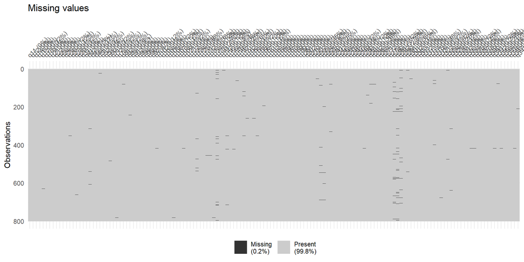

The most missing (2.62% to 3.75%) were in items assessing issues related to income (q280,q281,q282) and item q135 assessing trustworthiness of a known fake-news outlet. The income items also showed the most common intersections (same items missing from the same participants).

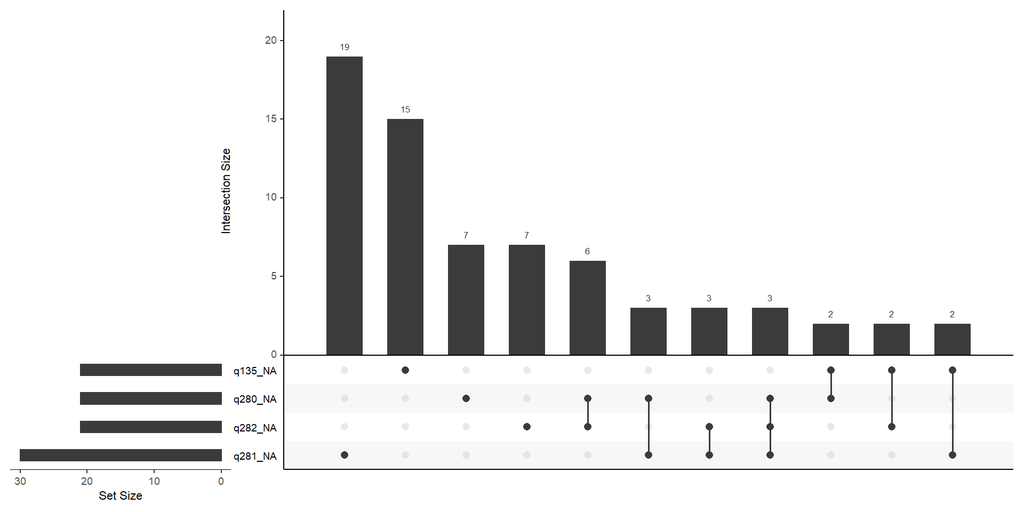

Based on the non-parametric test of heteroscedasticity, the assumption of missing completely at random (MCAR) was rejected for the numeric data (p = 0.001), but the overall amount of missing data in the dataset is very small.

# 2. Geographical distribution of participants

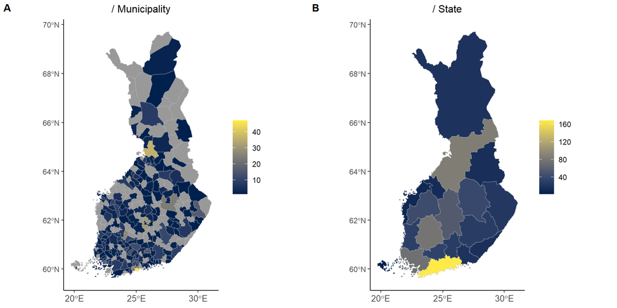

There were participants from 554 unique zip codes, of which 525 were valid. In total 770 participants gave a valid zip code (i.e. 30 participants had reported a incorrect zip code, see also Table 1). The zip codes were from 184 different municipalities from all states in Finland[^1].

# 3. Current status

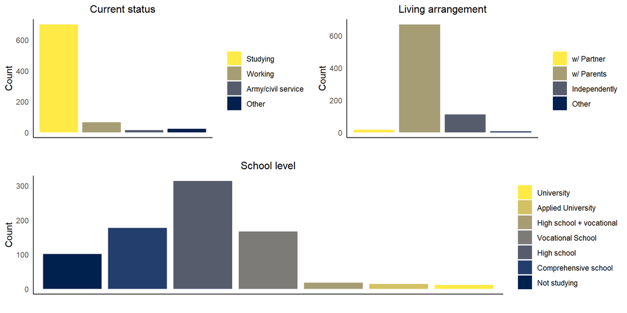

Most of the participants current status (see also Table 3) were either comprehensive school or secondary education student, who still lived their parents (Table 4).

# 4. Socio-economic status

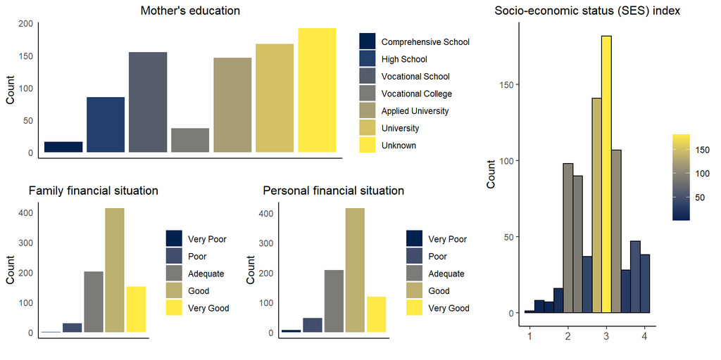

Examination of the participants socio-economic status indicated that the sample comprised of a representative distribution of young people from low to high socio-economic status. The majority reported that their mother had acquired at least a secondary degree and were in an adequate to good financial situation (see also Tables 5 and 6).

# Tables

Regional distribution of Participants

| Region | Participants | % |
| --- | --- | --- |
| Ahvenanmaa | 1 | 0.00 |
| Etelä-Karjala | 16 | 0.02 |
| Etelä-Pohjanmaa | 41 | 0.05 |
| Etelä-Savo | 27 | 0.04 |
| Kainuu | 15 | 0.02 |
| Kanta-Häme | 33 | 0.04 |
| Keski-Pohjanmaa | 13 | 0.02 |
| Keski-Suomi | 55 | 0.07 |
| Kymenlaakso | 18 | 0.02 |
| Lappi | 18 | 0.02 |
| Pirkanmaa | 78 | 0.10 |
| Pohjanmaa | 9 | 0.01 |
| Pohjois-Karjala | 23 | 0.03 |
| Pohjois-Pohjanmaa | 86 | 0.11 |
| Pohjois-Savo | 38 | 0.05 |
| Päijät-Häme | 27 | 0.04 |
| Satakunta | 30 | 0.04 |
| Uusimaa | 168 | 0.22 |
| Varsinais-Suomi | 74 | 0.10 |

Age and Gender distribution

| Sex | Value | 15 Years | 16 Years | 17 Years | 18 Years | 19 Years |
| --- | --- | --- | --- | --- | --- | --- |
| Male | n | 78 | 83 | 80 | 79 | 79 |
|  | % | 10 | 10 | 10 | 10 | 10 |
| Female | n | 77 | 84 | 79 | 79 | 82 |
|  | % | 10 | 10 | 10 | 10 | 10 |

Educational level (or occupational status)

| Level | Value | Studying | Working | Army/civil service | Other |
| --- | --- | --- | --- | --- | --- |
| Not studying | n | 0 | 64 | 14 | 23 |
|  | % | 0 | 8 | 2 | 3 |
| Comprehensive school | n | 177 | 0 | 0 | 0 |
|  | % | 22 | 0 | 0 | 0 |
| High school | n | 313 | 0 | 0 | 0 |
|  | % | 39 | 0 | 0 | 0 |
| Vocational school | n | 166 | 0 | 0 | 0 |
|  | % | 21 | 0 | 0 | 0 |
| High school + vocational | n | 18 | 0 | 0 | 0 |
|  | % | 2 | 0 | 0 | 0 |
| Applied college | n | 14 | 0 | 0 | 0 |
|  | % | 2 | 0 | 0 | 0 |
| University | n | 11 | 0 | 0 | 0 |
|  | % | 1 | 0 | 0 | 0 |

Living arrangements

|  | w/ Partner | w/ Parents | Independently | Other |
| --- | --- | --- | --- | --- |
| n | 16 | 668 | 110 | 6 |
| % | 2 | 84 | 14 | 1 |

Mother’s educational level

|  | Comprehensive School | High School | Vocational School | Vocational College | Applied University | University | Unknown |
| --- | --- | --- | --- | --- | --- | --- | --- |
| n | 16 | 85 | 155 | 37 | 146 | 168 | 192 |
| % | 2 | 11 | 19 | 5 | 18 | 21 | 24 |

Financial situation

| Variable | Value | Very Poor | Poor | Adequate | Good | Very Good |
| --- | --- | --- | --- | --- | --- | --- |
| Family | n | 1 | 30 | 203 | 414 | 152 |
|  | % | 0 | 4 | 25 | 52 | 19 |
| Personal | n | 7 | 47 | 208 | 416 | 119 |
|  | % | 1 | 6 | 26 | 52 | 15 |

[^1]: geofi package was used: Markus Kainu, Joona Lehtomäki, Juuso Parkkinen, Jani Miettinen, Leo Lahti Retrieval and analysis of open geospatial data from Finland with the geofi R package. R package version 0.9.2900006. URL: http://ropengov.github.io/geofi